# Tutorial

`growR` implements the grassland growth model ModVege. The basis of the model is thoroughly described by (Jouven, Carrère, and Baumont 2006).

In short, ModVege takes values relating to daily weather conditions, the nutrition availability and water holding capabilities as well as the prevailing functional composition of plant population of the simulated site as inputs and uses them to simulate grass growth on a daily time step.

Functions and data provided by `growR` allow users to

- run grass growth simulations with ModVege,
- calibrate site and model parameters on the basis of reference data,
- carry out basic analysis into model outputs and performance.

The following section provides a step-by-step tutorial intended to show how `growR` can be used. Deeper insights can be gained by the `vignette("parameter_descriptions")`.

## Step 0: Goal of the tutorial

In this tutorial we are going to make use of the example input and reference datasets to go through the whole process of

1. setting up all input files
2. running ModVege simulations with the specified inputs
3. have a look at the results
4. change inputs and run a new simulation

Since quite a number of input files are required to even get started with `growR`, the package ships with example files for each of them. When following the tutorial, the reader will have an opportunity to inspect all of them and can use those as templates in order to create their own simulations with their own data.

When running simulations, data is loaded from and written to files. In the following, we assume that we are working in an empty directory of the filesystem and that this is the working directory for the running `R` sessions or `Rscript` commands. To be on the safe side, for this tutorial we will create a temporary directory `working_dir`. All necessary or created files are assumed to be located under this working directory.

```r
working_dir = file.path(tempdir(), "growR_tutorial")
dir.create(working_dir)
setwd(working_dir)
```

## Step 1: Setting up all input files

To help users having a somewhat clean directory structure, the function `setup_directory()` is provided. It also offers the option to copy all example files from the package directory into appropriate location in the newly created directory structure. Our first step is therefore to execute the following from an `R` session:

```r
library(growR)
# Check that working directory is correct
print(working_dir)
```

```
#> [1] "/tmp/Rtmp5Izvk9/growR_tutorial"
```

```r
getwd()
```

```
#> [1] "/tmp/Rtmp5Izvk9/growR_tutorial"
```

```r
setup_directory(working_dir, force = TRUE)
```

```
#> [INFO]Initialized directory structure in `/tmp/Rtmp5Izvk9/growR_tutorial`.
#> [INFO]Copying `/tmp/RtmpIXr8w7/Rinst109d769448d26/growR/extdata/posieux_weather.txt` to `/tmp/Rtmp5Izvk9/growR_tutorial/input/`.
#> [INFO]Copying `/tmp/RtmpIXr8w7/Rinst109d769448d26/growR/extdata/posieux_parameters.csv` to `/tmp/Rtmp5Izvk9/growR_tutorial/input/`.
#> [INFO]Copying `/tmp/RtmpIXr8w7/Rinst109d769448d26/growR/extdata/posieux_management1.txt` to `/tmp/Rtmp5Izvk9/growR_tutorial/input/`.
#> [INFO]Copying `/tmp/RtmpIXr8w7/Rinst109d769448d26/growR/extdata/posieux_management2.txt` to `/tmp/Rtmp5Izvk9/growR_tutorial/input/`.
#> [INFO]Copying `/tmp/RtmpIXr8w7/Rinst109d769448d26/growR/extdata/sorens_weather.txt` to `/tmp/Rtmp5Izvk9/growR_tutorial/input/`.
#> [INFO]Copying `/tmp/RtmpIXr8w7/Rinst109d769448d26/growR/extdata/sorens_parameters.csv` to `/tmp/Rtmp5Izvk9/growR_tutorial/input/`.
#> [INFO]Copying `/tmp/RtmpIXr8w7/Rinst109d769448d26/growR/extdata/sorens_management1.txt` to `/tmp/Rtmp5Izvk9/growR_tutorial/input/`.
#> [INFO]Copying `/tmp/RtmpIXr8w7/Rinst109d769448d26/growR/extdata/sorens_management2.txt` to `/tmp/Rtmp5Izvk9/growR_tutorial/input/`.
#> [INFO]Copying `/tmp/RtmpIXr8w7/Rinst109d769448d26/growR/extdata/posieux1.csv` to `/tmp/Rtmp5Izvk9/growR_tutorial/data/`.
#> [INFO]Copying `/tmp/RtmpIXr8w7/Rinst109d769448d26/growR/extdata/posieux2.csv` to `/tmp/Rtmp5Izvk9/growR_tutorial/data/`.
#> [INFO]Copying `/tmp/RtmpIXr8w7/Rinst109d769448d26/growR/extdata/sorens1.csv` to `/tmp/Rtmp5Izvk9/growR_tutorial/data/`.
#> [INFO]Copying `/tmp/RtmpIXr8w7/Rinst109d769448d26/growR/extdata/sorens2.csv` to `/tmp/Rtmp5Izvk9/growR_tutorial/data/`.
#> [INFO]Copying `/tmp/RtmpIXr8w7/Rinst109d769448d26/growR/extdata/example_config.txt` to `/tmp/Rtmp5Izvk9/growR_tutorial`.
#> [INFO]Copying `/tmp/RtmpIXr8w7/Rinst109d769448d26/growR/scripts/compare.R` to `/tmp/Rtmp5Izvk9/growR_tutorial`.
#> [INFO]Copied example files to respective directories.
```

We used `force = TRUE` here such that we can skip the safety prompt which would otherwise ask for confirmation.

Afterwards, check the working directory. You should find a couple of subdirectories and some files:

- `output` This is where generated output will be written to, by default
- `input` Inputs to the simulation, such as weather and management data are stored here.
- `data` Experimentally measured, real world data comes here.

First, we’ll have a look at `example_config.txt`. We are later going to adjust and make use of this file for running our simulation in this tutorial. It contains information about the types of simulation we want to run and what input files should be used for each simulation. Have a look at its structure and compare it to the explanations given in the documentation of `read_config()`.

As you can infer, in order to completely run a simulation, we require at least a parameter and a weather data file (the management file is optional). `growR` comes with example data for two real-world experimental sites: Sorens and Posieux, both in Switzerland. You can find the respective example parameter files at `input/sorens_parameters.csv` and `input/posieux_parameters.csv`. Likewise for the `input/..._weather.txt` and `input/..._management1/2.txt` files. Again, have a look at these files and the respective descriptions in `WeatherData` and `ManagementData` to familiarize yourself with the required data structures and the meaning of the different columns.

## 2. Run ModVege with the example configuration

Everything is now set up for us and we are ready to proceed with a simulation. Run:

```r
environments = read_config("example_config.txt")
```

As you may have already seen from the documentation of `read_config()`, this reads in the given configuration file, skipping any lines starting with `#`. For each line, it then looks for the given input files and creates a `ModvegeEnvironment` object with the data from the corresponding files. These `ModvegeEnvironment`s are essentially data structures that hold all the information needed in order to run a ModVege simulation.

We are now ready to do so:

```r
results = growR_run_loop(environments,
                         output_dir = file.path(working_dir, "output"))
```

```
#> [INFO]Starting run 1 out of 2.
#> [INFO][Run 1/2]Simulating year 2013 (1/3)
#> [INFO][Run 1/2]Simulating year 2014 (2/3)
#> [INFO][Run 1/2]Simulating year 2015 (3/3)
#> [INFO]Starting run 2 out of 2.
#> [INFO][Run 2/2]Simulating year 2013 (1/3)
#> [INFO][Run 2/2]Simulating year 2014 (2/3)
#> [INFO][Run 2/2]Simulating year 2015 (3/3)
#> [INFO]All runs completed.
```

This will simulate grass growth for every year in every environment present in `environments`. After some console output, we now have the results of these runs in the list `results`. Check the documentation of `growR_run_loop()` ro see how this list is organized.

Furthermore, the default value for `write_files` in `growR_run_loop()` is `TRUE`. This means that the results have also been written to files in the `output` directory.

## 3. Have a look at the results

Since we have the simulation results at our fingertips in our interactive `R` sessions, the quickest way to inspect them is through the `results` list. The output of

```r
# Just print the first years of the first run (i.e. year 2013 at site Sorens)
results[[1]][[1]]
```

```
#> <ModvegeSite>
#>   Public:
#>     ABSDR: 0
#>     ABSDV: 0
#>     AET: 0.425137788528002 0.4583695833186 0.514875174072729 0.59 ...
#>     AgeDR: 502.41 502.7 502.7 505.98 510.39 512.89 512.89 514.12 51 ...
#>     AgeDRp: 3059.75216179612
#>     AgeDV: 502.41 502.7 502.7 505.98 510.39 512.89 512.89 514.12 51 ...
#>     AgeDVp: 386.16448511003
#>     AgeGR: 0 0 0 0 0 0 0 0 0 0 0 0 0 0 0 0 0 0 0 0 0 0 0 0 0 0 0 0  ...
#>     AgeGRp: 2295.17765333274
#>     AgeGV: 102.41 102.7 102.7 105.98 110.39 112.89 112.89 114.12 11 ...
#>     AgeGVp: 370.305478622553
#>     BM: 747.7587 747.490907997 747.490907997 744.464666239853 74 ...
#>     BMDR: 29.9277 29.919020967 29.919020967 29.8208865782282 29.68 ...
#>     BMDRp: 0.500130124356253
#>     BMDV: 297.831 297.57188703 297.57188703 294.643779661625 290.7 ...
#>     BMDVp: 282.480007964592
#>     BMG: 420 420 420 420 420 420 420 420 420 420 420 420 420 420  ...
#>     BMGR: 0 0 0 0 0 0 0 0 0 0 0 0 0 0 0 0 0 0 0 0 0 0 0 0 0 0 0 0  ...
#>     BMGRp: 140
#>     BMGV: 420 420 420 420 420 420 420 420 420 420 420 420 420 420  ...
#>     BMGVp: 491.4387683326
#>     BM_after_cut: 1070
#>     ENV: 0 0 0 0 0 0 0 0 0 0 0 0 0 0 0 0 0 0 0 0 0 0 0 0 0 0 0 0  ...
#>     ENVfPAR: 1 1 1 1 1 1 1 1 1 1 1 1 1 1 1 1 1 1 1 1 1 1 1 1 1 1 1 1  ...
#>     ENVfT: 0 0 0 0 0 0 0 0 0 0 0 0 0 0 0 0 0 0 0 0 0 0 0 0 0 0 0 0  ...
#>     ENVfW: 1 1 1 1 1 1 1 1 1 1 1 1 1 1 1 1 1 1 1 1 1 1 1 1 1 1 1 1  ...
#>     GRO: 0 0 0 0 0 0 0 0 0 0 0 0 0 0 0 0 0 0 0 0 0 0 0 0 0 0 0 0  ...
#>     GROGR: 0
#>     GROGV: 0
#>     LAI: 0.811104 0.811104 0.811104 0.811104 0.811104 0.811104 0. ...
#>     LAIGV: 0.811104 0.811104 0.811104 0.811104 0.811104 0.811104 0. ...
#>     OMD: 0.677537527475466 0.677569768025088 0.677569768025088 0. ...
#>     OMDDR: 0.4 0.4 0.4 0.4 0.4 0.4 0.4 0.4 0.4 0.4 0.4 0.4 0.4 0.4  ...
#>     OMDDV: 0.45 0.45 0.45 0.45 0.45 0.45 0.45 0.45 0.45 0.45 0.45 0 ...
#>     OMDG: 0.858665597014925 0.858576865671642 0.858576865671642 0. ...
#>     OMDGR: 0.89 0.89 0.89 0.89 0.89 0.89 0.89 0.89 0.89 0.89 0.89 0 ...
#>     OMDGV: 0.858665597014925 0.858576865671642 0.858576865671642 0. ...
#>     PGRO: 0 0 0 0 0 0 0 0 0 0 0 0 0 0 0 0 0 0 0 0 0 0 0 0 0 0 0 0  ...
```

[output cut: 54 more lines]

```
#>   Private:
#>     REP_ON: 0.653846153846154
#>     apply_cuts: function ()
#>     calculate_ageing: function ()
#>     calculate_digestibility: function ()
#>     calculate_growth: function ()
#>     carry_over_from_last_day: function ()
#>     check_if_simulation_has_run: function ()
#>     current_DOY: 365
#>     get_start_of_growing_season: function (critical_temperature = 5, consider_snow = FALSE, critical_snow = 1)
#>     initialize_state_variables: function ()
#>     make_header: function ()
#>     update_biomass: function ()
#>     vars_to_exclude: OMDDV OMDDR
#>     ylabels: list
```

might be a little overwhelming and not very helpful, though. A convenient way to quickly see what has happened is to plot the resulting grass growth curves. The `ModvegeSite` objects which are actually what’s stored in `results` provide a simple means of doing that through their `plot()` method.

For example, to see the growth curves for year 2013 at site Sorens we could do:

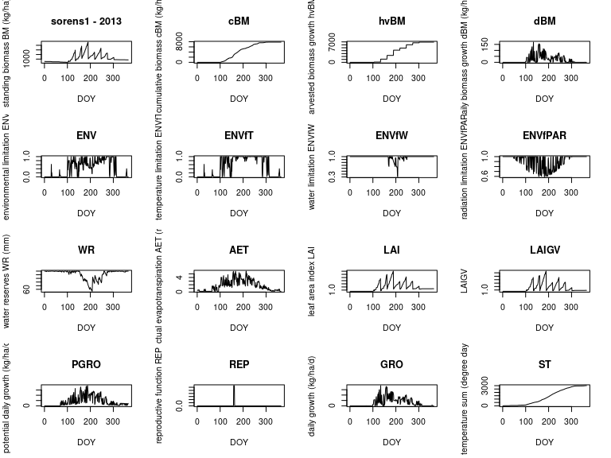

```r
results[[1]][[1]]$plot()
```

Excellent! You have run your first ModVege simulation with `growR`!

## 4. Change inputs and run a different simulation

Now, for the sake of the example, let’s say that you want to check what the simulation would look like if both sides had a significantly lower nutritional index `NI`. First, check the current values of `NI` in the differnet parameter files (`input/sorens_parameters.csv` and `input/posieux_parameters.csv`). They should be 0.7 for both sites.

We want to investigate what the growth curves look like for different values of NI. For that purpose, we’ll focus only on the site Sorens and only on the year 2013 (just to keep the calculations required for the example quick).

One way to supply different parameters to the simulation, is by providing different parameter files. Copy `sorens_parameters.csv` twice and call the copies something like `sorens_parameters_lowNI.csv` and `sorens_parameters_highNI.csv`. In one of the files, change the value of NI to 0.5 and in the other, change it to 1.0.

Then, copy the `example_config.txt` file, give it a name of your choice (we’ll use `NI_screening.txt` here) and edit it such that there are only three uncommented lines. All of them should use *site name* sorens1 and only the year 2013. One of them should use the original `sorens_parameters.csv` file while the others should use the newly written parameter files with higher and lower `NI` values respectively. Since we now specify several runs with the same *site name*, we need to distinguish them by giving at least two of them a distinct *run name* as well.

When done, your new config file might look something like this:

```
# site name     # run name  # year(s)   # param file            # weather data          # cut dates
sorens1     -   2013    sorens_parameters.csv   sorens_weather.txt      sorens_management1.txt
sorens1     lowNI   2013    sorens_parameters_lowNI.csv sorens_weather.txt      sorens_management1.txt
sorens1     highNI      2013    sorens_parameters_highNI.csv    sorens_weather.txt      sorens_management1.txt
```

Be sure that the spelling of your file names is correct and consistent and that all the files reside in the correct locations (i.e. the `input` directory under our working directory).

If all seems fine, go for it (use the name of the config file you chose):

```
new_envs = read_config("NI_screening.txt")
```

And we’re ready to run and inspect our next run of simulations:

```r
new_results = growR_run_loop(new_envs)
```

```
#> [INFO]Starting run 1 out of 3.
#> [INFO][Run 1/3]Simulating year 2013 (1/1)
#> [INFO]Starting run 2 out of 3.
#> [INFO][Run 2/3]Simulating year 2013 (1/1)
#> [INFO]Starting run 3 out of 3.
#> [INFO][Run 3/3]Simulating year 2013 (1/1)
#> [INFO]All runs completed.
```

```
#> [1] 0.7
```

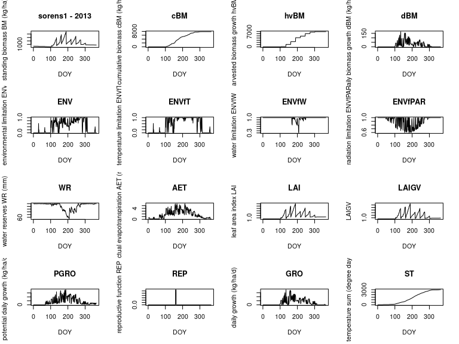

```
#> [1] 0.5
```

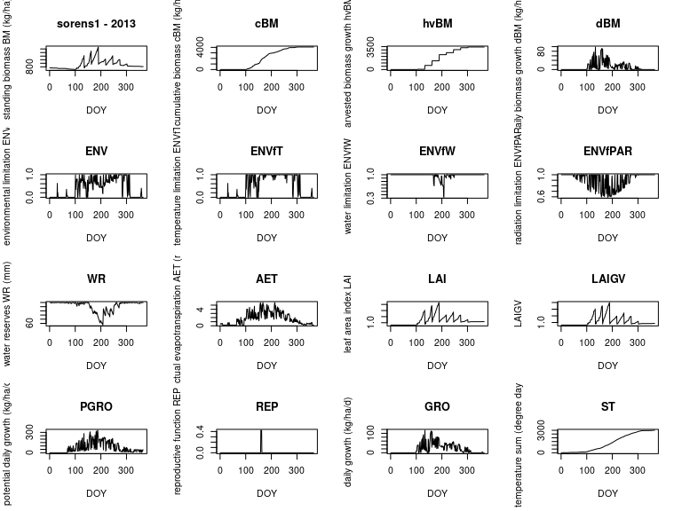

```
#> [1] 1
```

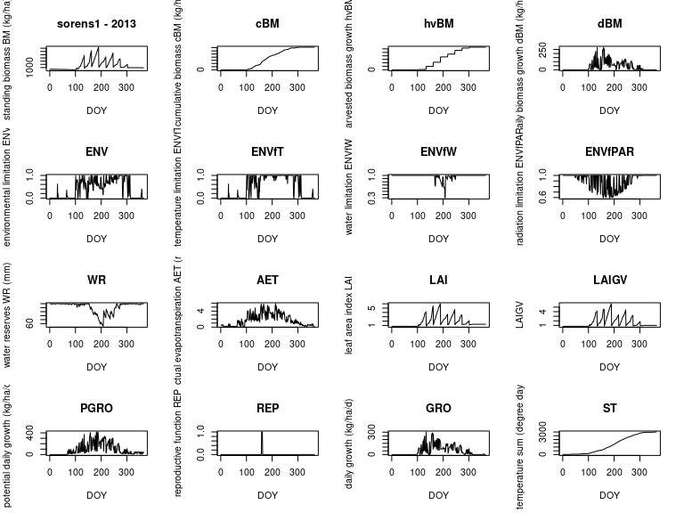

```r
# Plot all results
for (run in new_results) {
  print(run[[1]]$parameters$NI)
  run[[1]]$plot()
}
```

Jouven, M., P. Carrère, and R. Baumont. 2006. “Model Predicting Dynamics of Biomass, Structure and Digestibility of Herbage in Managed Permanent Pastures. 1. Model Description.” *Grass and Forage Science* 61 (2): 112–24. https://doi.org/10.1111/j.1365-2494.2006.00515.x.